# Diagnóstico de neumonía dadas imágenes de Rayos X de pacientes con neumonías y normales

*Hipótesis*: clasificar correctamente a pacientes con neumonía dadas imágenes en Rayos X con diagnóstico normal y de neumonía.

Lo más importante es predecir correctamente a los pacientes con neumonía. Conlleva más riesgo clasificar sin neumonía a un paciente con neumonía que al contrario (error tipo I), por lo que quiero minimzar los Falsos Negativos.

Dado el desequilibrio de clases, elijo el estadístico Kappa para evitar obtener una alta precisión al adivinar siempre la clase más frecuente. El estadístico kappa solo recompensará al clasificador si es correcto con más frecuencia que esta estrategia simplista.

También quiero conseguir un buen estadístico de sensibilidad prediciendo la mayor cantidad de pacientes con neumonía de todos los pacientes con neumonía existentes. Y una buena precisión del valor positivo predictivo (acertar la mayor cantidad de pacientes con neumonía del total de pacientes con neumonía predichos).

*Técnicas a utilizar*, diferentes técnicas de ML para clasificación y DL con uso de keras:

# Carga de librerías

```r
#devtools::install_github("rstudio/tensorflow")
#library(tensorflow)
#install_tensorflow()
#library(keras)
#install_keras() # instala tensorflow creando un vnv en python
library(tensorflow)
library(keras)
library(plyr)
library(dplyr)
library(ggplot2)
library(magrittr)
library(tidyr)
library(caret)
library(magick)
library(fs)
library(abind)
library(imager)
library(purrr)
```

# Estadísticos a evaluar

```r
# funciones para evaluar los estadísticos objetivo
statistics <- function(model, test_data) {
  library(vcd)
  kappa <- Kappa(table(model, test_data))$Weighted["value"]
  sens <- sensitivity( model, test_data, positive = "PNEUMONIA")
  spec <- specificity( model, test_data, positive = "NORMAL")
  pos_pred_val <- posPredValue( model, test_data, positive = "PNEUMONIA")

  print(paste0('El estadístico kappa es de ', round(kappa,3),'.'))
  print(paste0('El estadístico recall, la proporción de predicciones de neumonías correctamente clasificadas entre todas las neumonías, es de ',round(sens,3),'.'))
  print(paste0('El positive predictive value, la proporción de las predicciones de neumonías que son realmente neumonías, es de ', round(pos_pred_val,3),'.'))
  print(paste0('El estadístico specifity, la proporción de predicciones de condición normal correctamente clasificadas entre todas las condiciones normales, es de ',round(spec,3),'.'))
}
```

# Fuente de datos

Datos cargados en diferentes conjuntos de entrenamiento, validación y test.

```r
train_data = "/Users/saranavarromedina/Desktop/thisisit/train"
val_data = "/Users/saranavarromedina/Desktop/thisisit/val"
test_data = "/Users/saranavarromedina/Desktop/thisisit/test"
```

Creación de dataframe para explorar los datos

```r
df_creation <- function(dataset_choosen) {
  xrays <- list.dirs(path = dataset_choosen)
  xrays <- lapply(xrays, function(x) list.files(path = x, pattern = "*.jpeg", full.names = TRUE))
  #rm(c)
  xrays <- do.call(c, xrays)

  # Ajuste de tamaño de las imágenes de rayos X.
  df <- lapply(xrays, function(x) {
      im <- load.image(x)
      im <- grayscale(im)
      im <- resize(im, 100, 100)
      df <- c(as.data.frame(im)$value * 255.0, condition = basename(dirname(x)))
   })
  df <- as.data.frame(do.call("rbind", df))
  df
}

df_train <- df_creation(train_data)
df_test <- df_creation(test_data)
df_val <- df_creation(val_data)
```

```r
df_train[, 1:10000] <- sapply(df_train[, 1:10000], as.numeric)
df_test[, 1:10000] <- sapply(df_test[, 1:10000], as.numeric)
df_val[, 1:10000] <- sapply(df_val[, 1:10000], as.numeric)
```

# Exploración de dataframe con imágenes transformadas de 100x100 píxeles

```r
dim(df_train)
```

```
[1]  4478 10001
```

```r
dim(df_test)
```

```
[1]  1034 10001
```

```r
dim(df_val)
```

```
[1]   344 10001
```

Imágenes de 100x100 píxeles con su correspondiente clasificación. División de imágenes en train (4478), test (1034) y validación (344).

Visualización de imágenes de rayos X con y sin neumonía

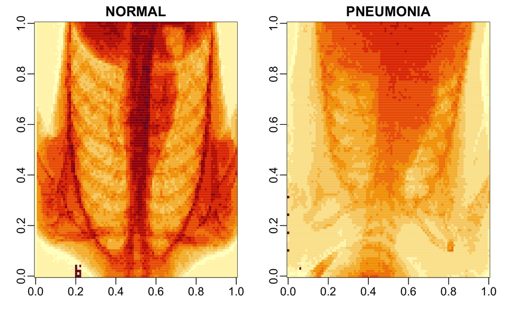

```r
rafalib::mypar()

img_normal <- matrix(df_train[1,], 100, 100)
mode(img_normal) <- "numeric"
img_neumonia <- matrix(df_train[2985,], 100, 100)
mode(img_neumonia) <- "numeric"
layout(t(1:2))
image(img_normal, main = df_train[1,]$condition)
image(img_neumonia, main = df_train[2985,]$condition)
```

## ¿Hay desequilibrio entre las clases de imágenes con y sin neumonía?

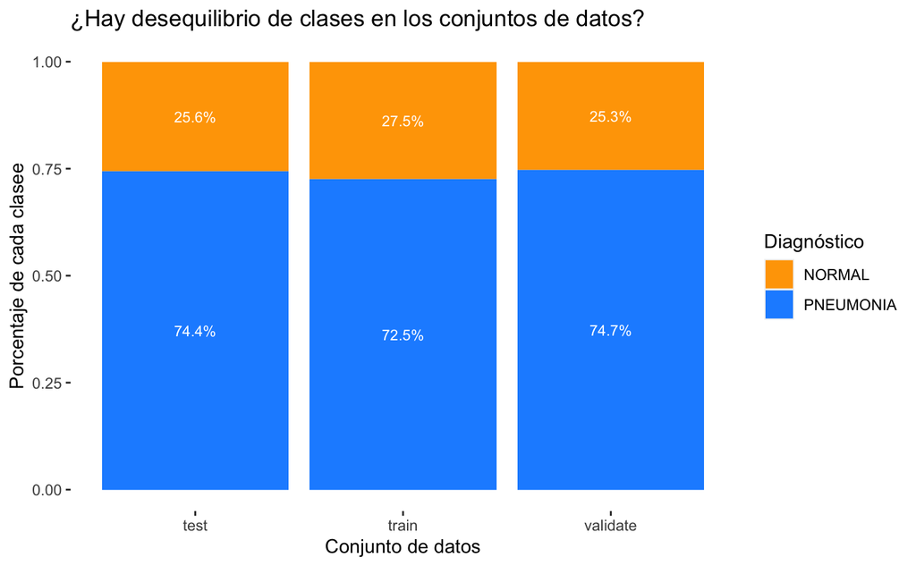

```r
train_per <- df_train %>% group_by(condition) %>% dplyr::summarize(n = n()) %>% mutate(type = "train", percent = n /sum(n))

test_per <- df_test %>% group_by(condition) %>% dplyr::summarize(n = n()) %>% mutate(type = "test", percent = n /sum(n))

val_per <- df_val %>% group_by(condition) %>% dplyr::summarize(n = n()) %>% mutate(type = "validate", percent = n /sum(n))

data_per <- rbind(train_per, test_per, val_per)

ggplot(data_per, aes(fill = condition, y = percent, x = type)) +
  geom_bar(position = "fill", stat = "identity") +
  scale_fill_manual(values=c("#FFA500", "#1E90FF")) +
  geom_text(aes(label = paste0(sprintf("%1.1f", percent * 100), "%")), position = position_stack(vjust = 0.5), colour = "white", size = 3) +
  ggtitle("¿Hay desequilibrio de clases en los conjuntos de datos?") +
  labs(x="Conjunto de datos", y="Porcentaje de cada clasee", fill="Diagnóstico") +

  theme(axis.line = element_blank(),
        panel.grid.major = element_blank(),
        panel.grid.minor = element_blank(),
        panel.border = element_blank(),
        panel.background = element_blank(),
        )
```

Hay un desequilibrio de clases que se mantiene en todos los conjuntos de datos. Más del 70% de las imágenes en cada conjunto son casos de neumonía. Por tanto, puede producirse un sesgo al detectar casos de neumonía.

# Modelos de ML y DL

## K-Means

```r
options(warn=-1)

set.seed(2345)
k <- kmeans(train_x, centers = 2, nstart = 25)
# Function to assign cluster
predict_kmeans <- function(x, k) {
  # asignar agrupaciones
  centers <- k$centers
  # distancia a los centros
  distances <- sapply(1:nrow(x), function(i) {
    apply(centers, 1, function(y) dist(rbind(x[i, ], y)))
  })
  # seleccionar la agrupación con la mínima distancia al centro
  max.col(-t(distances))
}
kmeans_pred <- predict_kmeans(test_x, k)
kmeans_pred <- ifelse(kmeans_pred == 1, "NORMAL", "PNEUMONIA")
statistics(as.factor(kmeans_pred),as.factor(df_test$condition))
```

```
[1] "El estadístico kappa es de 0.015."
[1] "El estadístico recall, la proporción de predicciones de neumonías correctamente clasificadas entre todas las neumonías, es de 0.636."
[1] "El positive predictive value, la proporción de las predicciones de neumonías que son realmente neumonías, es de 0.749."
[1] "El estadístico specifity, la proporción de predicciones de condición normal correctamente clasificadas entre todas las condiciones normales, es de 0.636."
```

Es llamativo como el estadístico Kappa es prácticamente 0 mientras que el resto supera el 0.6.

## Naive Bayes

```r
#install.packages("naivebayes")
library(naivebayes)
naive_model <- naive_bayes(condition ~ ., data = df_train, usekernel = T)#,laplace=1)
naive_pred <- predict(naive_model, df_test[ , -which(names(df_test) %in% c("condition"))])
naive_stats <- statistics(factor(naive_pred),factor(df_test$condition))
```

```
[1] "El estadístico kappa es de 0.423."
[1] "El estadístico recall, la proporción de predicciones de neumonías correctamente clasificadas entre todas las neumonías, es de 0.614."
[1] "El positive predictive value, la proporción de las predicciones de neumonías que son realmente neumonías, es de 0.977."
[1] "El estadístico specifity, la proporción de predicciones de condición normal correctamente clasificadas entre todas las condiciones normales, es de 0.614."
```

```r
naive_stats
```

```
[1] "El estadístico specifity, la proporción de predicciones de condición normal correctamente clasificadas entre todas las condiciones normales, es de 0.614."
```

## Bagging

```r
library(ipred)
set.seed(300)
#bag_model <- bagging(factor(condition) ~ ., data = df_train, nbagg = 8)
#bag_pred_prob <- predict(bag_model, df_test[ , -which(names(df_test) %in% c("condition"))],type='prob')
#bag_pred_prob <- as.data.frame(bag_pred_prob)
#bag_pred_prob$actual <- df_test$condition
#bag_pred_prob$prediction <- ifelse(bag_pred_prob$NORMAL >= 0.5, 'NORMAL', 'PNEUMONIA')

bag_stats <- statistics(factor(bag_pred_prob$prediction),factor(df_test$condition))
```

```
[1] "El estadístico kappa es de 0.7."
[1] "El estadístico recall, la proporción de predicciones de neumonías correctamente clasificadas entre todas las neumonías, es de 0.869."
[1] "El positive predictive value, la proporción de las predicciones de neumonías que son realmente neumonías, es de 0.96."
[1] "El estadístico specifity, la proporción de predicciones de condición normal correctamente clasificadas entre todas las condiciones normales, es de 0.869."
```

```r
table(factor(bag_pred_prob$prediction), factor(df_test$condition))
```

```
            NORMAL PNEUMONIA
  NORMAL       237       101
  PNEUMONIA     28       668
```

```r
table(df_test$condition)
```

```
   NORMAL PNEUMONIA
      265       769
```

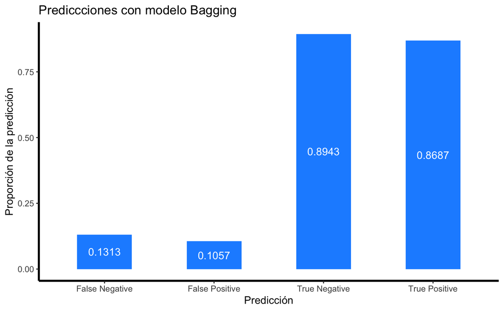

```r
# A la predicción anterior añado las probabilidades con las que RF predice cada clase
#bag_pred_prob <- predict(bag_model, df_test[ , -which(names(df_test) %in% c("condition"))],type='prob')

bag_plot <- as.data.frame(table(bag_pred_prob$prediction,bag_pred_prob$actual))
colnames(bag_plot) <- c('predicted','actual','value')
bag_plot$prop <- round(bag_plot$value / ifelse(bag_plot$actual=='NORMAL',265,769),4)
bag_plot$label <- c('True Negative','False Positive', 'False Negative', 'True Positive')

ggplot(bag_plot, aes(x=label, y=prop)) +
  geom_bar(stat="identity", width=.5, fill = "#1E90FF") +
  ggtitle("Prediccciones con modelo Bagging") +
  labs(x="Predicción", y="Proporción de la predicción", size="cantidad de pacientes predichos") +
  geom_text(aes(label=prop),position=position_stack(0.5), color='white') +
  theme(axis.line = element_line(size=1, colour = "black"),
        panel.grid.major = element_blank(),
        panel.grid.minor = element_blank(),
        panel.border = element_blank(),
        panel.background = element_blank(),
        )
```

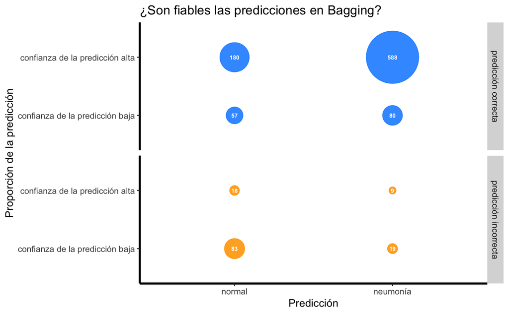

```r
# Creación de un dataframe y limpieza para poder crear un gráfico que muestre cómo de probable han sido las predicciones y la cantidad de casos con mayor y menor probabilidad de predecir una clase u otra.
bag_pred_prob <- as.data.frame(bag_pred_prob)
bag_pred_prob$actual <- df_test$condition

bag_pred_prob$prediction <- ifelse(bag_pred_prob$NORMAL >= 0.5, 'NORMAL', 'PNEUMONIA')

bag_pred_prob$pred_prob <- ifelse(bag_pred_prob$prediction=='PNEUMONIA', bag_pred_prob$PNEUMONIA,bag_pred_prob$NORMAL)

bag_pred_prob$success_pred <- ifelse(bag_pred_prob$actual == bag_pred_prob$prediction, 'predicción correcta','predicción incorrecta')

bag_pred_prob$cat_prop <- ifelse(bag_pred_prob$pred_prob<0.75,'confianza de la predicción baja','confianza de la predicción alta')

bag_pred_prob$cat_prop <- factor(bag_pred_prob$cat_prop, levels=c('confianza de la predicción baja','confianza de la predicción media','confianza de la predicción alta'))

bag_analysis <- bag_pred_prob %>% group_by(prediction, success_pred, cat_prop) %>% dplyr::summarise(casos=n(), .groups = 'drop')

xlabs_rename <- c('normal','neumonía')

ggplot(bag_analysis, aes(x=prediction,y=cat_prop)) +
  geom_point(aes(color=success_pred, size=casos),
             alpha = 0.9) +
  scale_size_area(max_size = 25) +
  facet_grid(success_pred ~ .) +
  geom_text(aes(label=casos,group=success_pred), size=2.1,color='white',fontface='bold') +
  ggtitle("¿Son fiables las predicciones en Bagging?") +
  labs(x="Predicción", y="Proporción de la predicción", size="cantidad de pacientes predichos") +
  scale_x_discrete(labels= xlabs_rename) +
  scale_color_manual(values=c("#1E90FF", "#FFA500")) +
  theme(axis.line = element_line(size=1, colour = "black"),
        panel.grid.major = element_blank(),
        panel.grid.minor = element_blank(),
        panel.border = element_blank(),
        panel.background = element_blank(),
        legend.key=element_blank(),
        legend.background=element_blank()
        ) +
  guides(size='none',color='none')
```

Dado que las predicciones correctas para ambas clases no son bajas (superan el 0.85): - Las predicciones de neumonía incorrectas son de 19 y 9 con probabilidad baja y alta respectivamente. - Las predicciones normales incorrectas son de 83 y 18 con probabilidad baja y alta respectivamente.

Decido utilizar la curva ROC para evaluar un modelo de clasificación de desequilibrio de clases dado que es insensible a la dstribución de clases y a la métrica no le importa cuántos casos positivos y negativos hay en el conjunto de datos.

```r
library(pROC)
roc(ifelse(bag_pred_prob$prediction=='NORMAL',0,1),ifelse(df_test$condition=='NORMAL',0,1), plot = TRUE,
    asp=NA,
    legacy.axes = TRUE,
    percent = TRUE,
    col = "#1E90FF",
    lwd = 3,
    print.auc = TRUE)
```

```
Call:
roc.default(response = ifelse(bag_pred_prob$prediction == "NORMAL",     0, 1), predictor = ifelse(df_test$condition == "NORMAL",     0, 1), percent = TRUE, plot = TRUE, asp = NA, legacy.axes = TRUE,     col = "#1E90FF", lwd = 3, print.auc = TRUE)

Data: ifelse(df_test$condition == "NORMAL", 0, 1) in 338 controls (ifelse(bag_pred_prob$prediction == "NORMAL", 0, 1) 0) < 696 cases (ifelse(bag_pred_prob$prediction == "NORMAL", 0, 1) 1).
Area under the curve: 83.05%
```

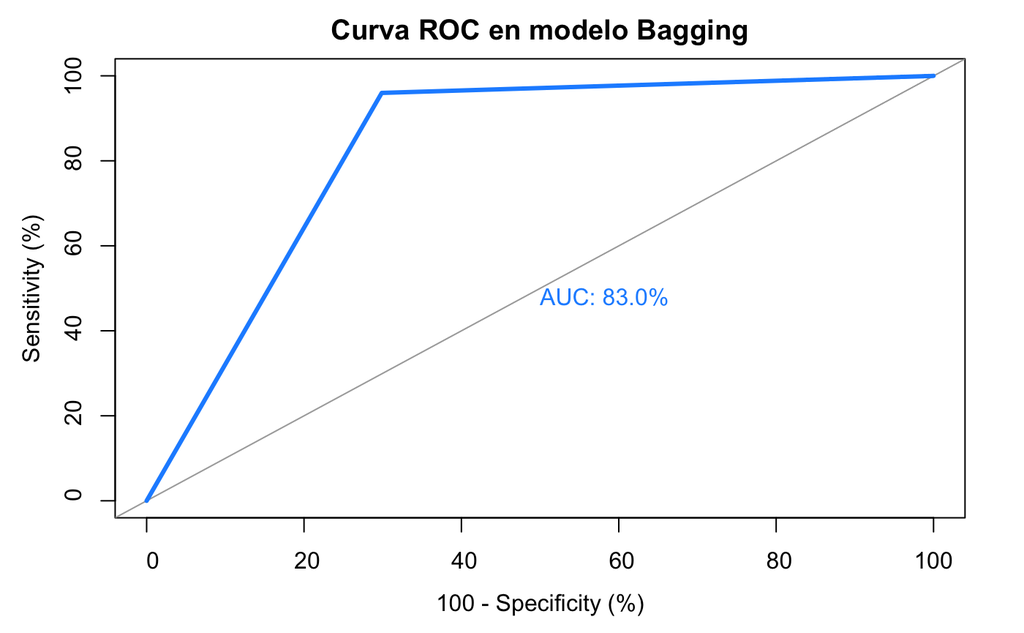

```r
title('Curva ROC en modelo Bagging')
```

La sensibilidad o recall y la especificidad son de 0.869, como se ha especificado anteriormente en la impresión del valor de los estadísticos. El Área bajo la curva ROC (AUC) es de 83%, por lo que el funcionamiento del modelo es bastante mejor que los anteriores. Como el valor de Kappa no es muy alto 0.7 y el error tipo I es de 0.13% debo seguir buscando un modelo más óptimo.

## Random Forest

```r
library(randomForest)
set.seed(300)
rf_model <- randomForest(factor(condition) ~ ., data = df_train)
rf_pred_prob <- predict(rf_model, df_test[ , -which(names(df_test) %in% c("condition"))],type='prob')

rf_pred_prob <- as.data.frame(rf_pred_prob)
rf_pred_prob$actual <- df_test$condition
rf_pred_prob$prediction <- ifelse(rf_pred_prob$NORMAL >= 0.5, 'NORMAL', 'PNEUMONIA')

rf_stats <- statistics(factor(rf_pred_prob$prediction),factor(df_test$condition))
```

```
[1] "El estadístico kappa es de 0.855."
[1] "El estadístico recall, la proporción de predicciones de neumonías correctamente clasificadas entre todas las neumonías, es de 0.965."
[1] "El positive predictive value, la proporción de las predicciones de neumonías que son realmente neumonías, es de 0.961."
[1] "El estadístico specifity, la proporción de predicciones de condición normal correctamente clasificadas entre todas las condiciones normales, es de 0.965."
```

```r
table(factor(rf_pred_prob$prediction), factor(df_test$condition))
```

```
            NORMAL PNEUMONIA
  NORMAL       235        27
  PNEUMONIA     30       742
```

```r
table(df_test$condition)
```

```
   NORMAL PNEUMONIA
      265       769
```

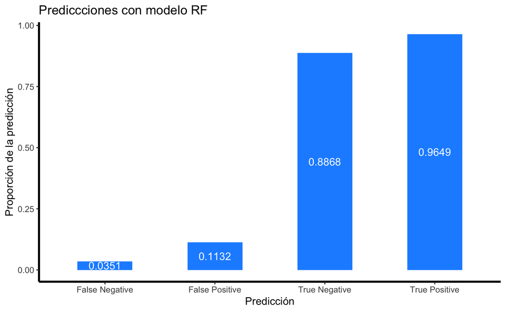

```r
# A la predicción anterior añado las probabilidades con las que RF predice cada clase
rf_plot <- as.data.frame(table(rf_pred_prob$prediction,rf_pred_prob$actual))
colnames(rf_plot) <- c('predicted','actual','value')
rf_plot$prop <- round(rf_plot$value / ifelse(rf_plot$actual=='NORMAL',265,769),4)
rf_plot$label <- c('True Negative','False Positive', 'False Negative', 'True Positive')

ggplot(rf_plot, aes(x=label, y=prop)) +
  geom_bar(stat="identity", width=.5, fill = "#1E90FF") +
  ggtitle("Prediccciones con modelo RF") +
  labs(x="Predicción", y="Proporción de la predicción", size="cantidad de pacientes predichos") +
  geom_text(aes(label=prop),position=position_stack(0.5), color='white') +
  theme(axis.line = element_line(size=1, colour = "black"),
        panel.grid.major = element_blank(),
        panel.grid.minor = element_blank(),
        panel.border = element_blank(),
        panel.background = element_blank(),
        )
```

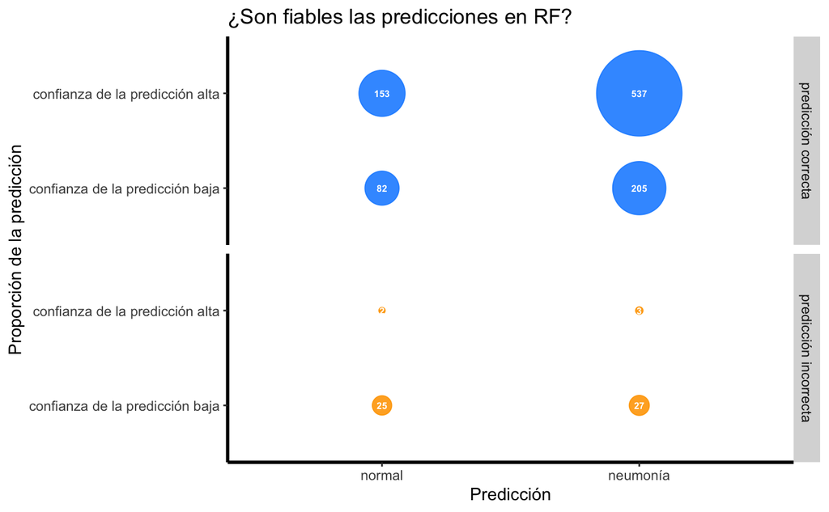

```r
# Creación de un dataframe y limpieza para poder crear un gráfico que muestre cómo de probable han sido las predicciones y la cantidad de casos con mayor y menor probabilidad de predecir una clase u otra.
rf_pred_prob$pred_prob <- ifelse(rf_pred_prob$prediction=='PNEUMONIA', rf_pred_prob$PNEUMONIA,rf_pred_prob$NORMAL)

rf_pred_prob$success_pred <- ifelse(rf_pred_prob$actual == rf_pred_prob$prediction, 'predicción correcta','predicción incorrecta')

rf_pred_prob$cat_prop <- ifelse(rf_pred_prob$pred_prob<0.75,'confianza de la predicción baja','confianza de la predicción alta')

rf_pred_prob$cat_prop <- factor(rf_pred_prob$cat_prop, levels=c('confianza de la predicción baja','confianza de la predicción media','confianza de la predicción alta'))

rf_analysis <- rf_pred_prob %>% group_by(prediction, success_pred, cat_prop) %>% dplyr::summarise(casos=n(), .groups = 'drop')

xlabs_rename <- c('normal','neumonía')

ggplot(rf_analysis, aes(x=prediction,y=cat_prop)) +
  geom_point(aes(color=success_pred, size=casos),
             alpha = 0.9) +
  scale_size_area(max_size = 25) +
  facet_grid(success_pred ~ .) +
  geom_text(aes(label=casos,group=success_pred), size=2.1,color='white',fontface='bold') +
  ggtitle("¿Son fiables las predicciones en RF?") +
  labs(x="Predicción", y="Proporción de la predicción", size="cantidad de pacientes predichos") +
  scale_x_discrete(labels= xlabs_rename) +
  scale_color_manual(values=c("#1E90FF", "#FFA500")) +
  theme(axis.line = element_line(size=1, colour = "black"),
        panel.grid.major = element_blank(),
        panel.grid.minor = element_blank(),
        panel.border = element_blank(),
        panel.background = element_blank(),
        legend.key=element_blank(),
        legend.background=element_blank()
        ) +
  guides(size='none',color='none')
```

Dado que las predicciones correctas para ambas clases no son bajas (superan el 0.88): - Las predicciones de neumonía incorrectas son de 27 y 3 con probabilidad baja y alta respectivamente. - Las predicciones normalese incorrectas son de 25 y 2 con probabilidad baja y alta respectivamente.

Decido utilizar la curva ROC para evaluar un modelo de clasificación de desequilibrio de clases dado que es insensible a la dstribución de clases y a la métrica no le importa cuántos casos positivos y negativos hay en el conjunto de datos.

```r
library(pROC)
roc(ifelse(rf_pred_prob$prediction=='NORMAL',0,1),ifelse(df_test$condition=='NORMAL',0,1), plot = TRUE,
    asp=NA,
    legacy.axes = TRUE,
    percent = TRUE,
    col = "#1E90FF",
    lwd = 3,
    print.auc = TRUE)
```

```
Call:
roc.default(response = ifelse(rf_pred_prob$prediction == "NORMAL",     0, 1), predictor = ifelse(df_test$condition == "NORMAL",     0, 1), percent = TRUE, plot = TRUE, asp = NA, legacy.axes = TRUE,     col = "#1E90FF", lwd = 3, print.auc = TRUE)

Data: ifelse(df_test$condition == "NORMAL", 0, 1) in 262 controls (ifelse(rf_pred_prob$prediction == "NORMAL", 0, 1) 0) < 772 cases (ifelse(rf_pred_prob$prediction == "NORMAL", 0, 1) 1).
Area under the curve: 92.9%
```

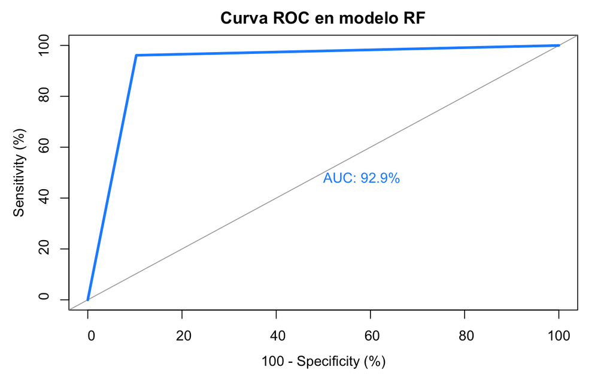

```r
title('Curva ROC en modelo RF')
```

La sensibilidad o recall y la especificidad son de 0.965, como se ha especificado anteriormente en la impresión del valor de los estadísticos. El Área bajo la curva ROC (AUC) es de un 92.9%, por lo que el funcionamiento del modelo es bueno. Hay errores tipo I (0.03%) bajos y una Kappa aceptable (0.855) que distingue corrcetamente a las clases diagnósticas.

Hasta el momento el modelo RF es el que mejor resultados ha obtenido.

## Support Vector Machine

```r
library(e1071)
svm_model <- svm(formula = factor(condition) ~ ., data = df_train, kernel = "linear", cost = 10, scale = FALSE, probability=TRUE)
```

```r
table(factor(svm_pred_prob$prediction), factor(df_test$condition))
```

```
            NORMAL PNEUMONIA
  NORMAL       243        62
  PNEUMONIA     22       707
```

```r
table(df_test$condition)
```

```
   NORMAL PNEUMONIA
      265       769
```

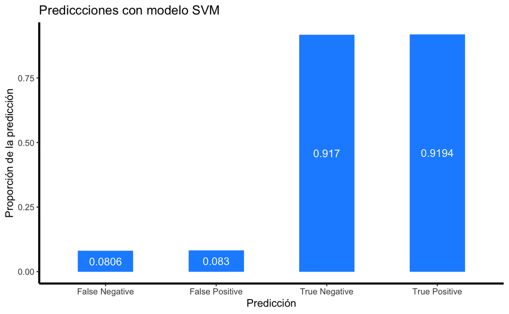

```r
# A la predicción anterior añado las probabilidades con las que RF predice cada clase
svm_plot <- as.data.frame(table(svm_pred_prob$prediction,svm_pred_prob$actual))
colnames(svm_plot) <- c('predicted','actual','value')
svm_plot$prop <- round(svm_plot$value / ifelse(svm_plot$actual=='NORMAL',265,769),4)
svm_plot$label <- c('True Negative','False Positive', 'False Negative', 'True Positive')

ggplot(svm_plot, aes(x=label, y=prop)) +
  geom_bar(stat="identity", width=.5, fill = "#1E90FF") +
  ggtitle("Prediccciones con modelo SVM") +
  labs(x="Predicción", y="Proporción de la predicción", size="cantidad de pacientes predichos") +
  geom_text(aes(label=prop),position=position_stack(0.5), color='white') +
  theme(axis.line = element_line(size=1, colour = "black"),
        panel.grid.major = element_blank(),
        panel.grid.minor = element_blank(),
        panel.border = element_blank(),
        panel.background = element_blank(),
        )
```

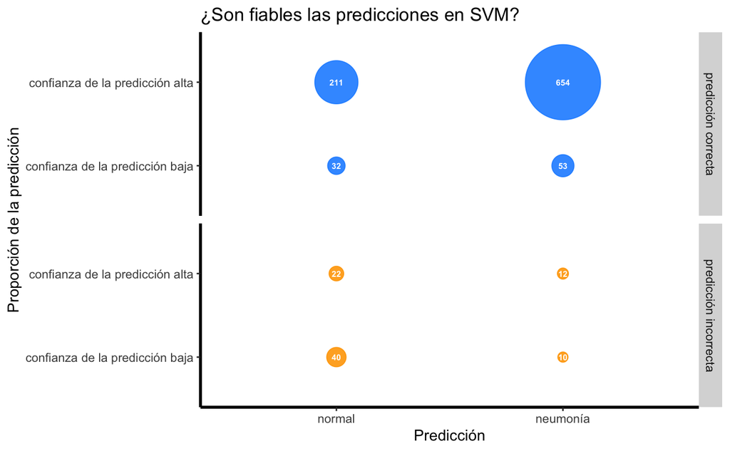

```r
# Creación de un dataframe y limpieza para poder crear un gráfico que muestre cómo de probable han sido las predicciones y la cantidad de casos con mayor y menor probabilidad de predecir una clase u otra.
svm_pred_prob$pred_prob <- ifelse(svm_pred_prob$prediction=='PNEUMONIA', svm_pred_prob$PNEUMONIA,svm_pred_prob$NORMAL)

svm_pred_prob$success_pred <- ifelse(svm_pred_prob$actual == svm_pred_prob$prediction, 'predicción correcta','predicción incorrecta')

svm_pred_prob$cat_prop <- ifelse(svm_pred_prob$pred_prob<0.75,'confianza de la predicción baja','confianza de la predicción alta')

svm_pred_prob$cat_prop <- factor(svm_pred_prob$cat_prop, levels=c('confianza de la predicción baja','confianza de la predicción media','confianza de la predicción alta'))

svm_analysis <- svm_pred_prob %>% group_by(prediction, success_pred, cat_prop) %>% dplyr::summarise(casos=n(), .groups = 'drop')

xlabs_rename <- c('normal','neumonía')

ggplot(svm_analysis, aes(x=prediction,y=cat_prop)) +
  geom_point(aes(color=success_pred, size=casos),
             alpha = 0.9) +
  scale_size_area(max_size = 25) +
  facet_grid(success_pred ~ .) +
  geom_text(aes(label=casos,group=success_pred), size=2.1,color='white',fontface='bold') +
  ggtitle("¿Son fiables las predicciones en SVM?") +
  labs(x="Predicción", y="Proporción de la predicción", size="cantidad de pacientes predichos") +
  scale_x_discrete(labels= xlabs_rename) +
  scale_color_manual(values=c("#1E90FF", "#FFA500")) +
  theme(axis.line = element_line(size=1, colour = "black"),
        panel.grid.major = element_blank(),
        panel.grid.minor = element_blank(),
        panel.border = element_blank(),
        panel.background = element_blank(),
        legend.key=element_blank(),
        legend.background=element_blank()
        ) +
  guides(size='none',color='none')
```

Dado que las predicciones correctas para ambas clases son altas (superan el 0.91): - Las predicciones de neumonía incorrectas son de 10 y 12 con probabilidad baja y alta respectivamente. - Las predicciones normales incorrectas son de 40 y 22 con probabilidad baja y alta respectivamente. decido utilizar la curva ROC.

```r
roc(ifelse(svm_pred_prob$prediction=='NORMAL',0,1),ifelse(df_test$condition=='NORMAL',0,1), plot = TRUE,
    asp=NA,
    legacy.axes = TRUE,
    percent = TRUE,
    col = "#1E90FF",
    lwd = 3,
    print.auc = TRUE)
```

```
Call:
roc.default(response = ifelse(svm_pred_prob$prediction == "NORMAL",     0, 1), predictor = ifelse(df_test$condition == "NORMAL",     0, 1), percent = TRUE, plot = TRUE, asp = NA, legacy.axes = TRUE,     col = "#1E90FF", lwd = 3, print.auc = TRUE)

Data: ifelse(df_test$condition == "NORMAL", 0, 1) in 305 controls (ifelse(svm_pred_prob$prediction == "NORMAL", 0, 1) 0) < 729 cases (ifelse(svm_pred_prob$prediction == "NORMAL", 0, 1) 1).
Area under the curve: 88.33%
```

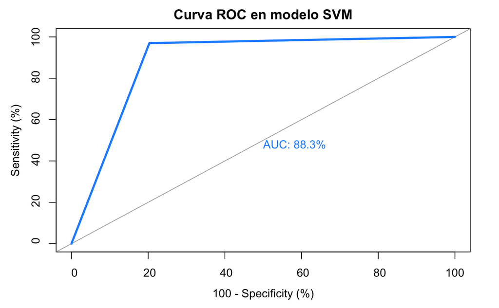

```r
title('Curva ROC en modelo SVM')
```

El modelo SVM es capaz de predecir con el diagnóstico normal con una probabilidad alta casi todos los casos que el modelo RF predice con confianza baja y alta. También es capaz de predecir con probabilidad alta más diagnósticos de neumonía correctamente que el modelo RF. Sin embargo, el modelo SVM comete más del doble de fallos prediciendo diagnósticos normales (que en realidad son neumonías) que el modelo RF. Este punto es el que determina qué modelo es mejor en este caso, ya que mi objetivo es minimizar los errores tipo I (que se diagnostique normal cuando es una neumonía). Quizá por esto se vea afectado negativamente en el valor de Kappa y de AUC (más bajo en el modelo SVM). El modelo RF es mejor modelo al cometer menos errores de tipo I y predecir correctamente más casos de neumonía (aunque con menor probabilidad de predicción).

## Regresión Logística

```r
library(glmnet)
set.seed(1, sample.kind = "Rounding")
rl_model <- cv.glmnet(
  x = as.matrix(df_train[ , -which(names(df_train) %in% c("condition"))]), y = df_train$condition,
  family = "binomial", type.measure = "class")

rl_model$lambda.1se
```

```
[1] 0.008071807
```

```r
rl_pred <- predict(rl_model, as.matrix(df_test[ , -which(names(df_test) %in% c("condition"))]), s = "lambda.1se", type = "class")
rl_pred <- as.vector(rl_pred)
rl_stats <- statistics(factor(rl_pred),factor(df_test$condition))
```

```
[1] "El estadístico kappa es de 0.809."
[1] "El estadístico recall, la proporción de predicciones de neumonías correctamente clasificadas entre todas las neumonías, es de 0.93."
[1] "El positive predictive value, la proporción de las predicciones de neumonías que son realmente neumonías, es de 0.968."
[1] "El estadístico specifity, la proporción de predicciones de condición normal correctamente clasificadas entre todas las condiciones normales, es de 0.93."
```

Este modelo se aproxima a los resultados obtenidos con Random Forest pero no consigue mejorarlos a excepción del positive predictive value.

```r
roc(ifelse(rl_pred=='NORMAL',0,1),ifelse(df_test$condition=='NORMAL',0,1), plot = TRUE,
    asp=NA,
    legacy.axes = TRUE,
    percent = TRUE,
    col = "#1E90FF",
    lwd = 3,
    print.auc = TRUE)
```

```
Call:
roc.default(response = ifelse(rl_pred == "NORMAL", 0, 1), predictor = ifelse(df_test$condition ==     "NORMAL", 0, 1), percent = TRUE, plot = TRUE, asp = NA, legacy.axes = TRUE,     col = "#1E90FF", lwd = 3, print.auc = TRUE)

Data: ifelse(df_test$condition == "NORMAL", 0, 1) in 295 controls (ifelse(rl_pred == "NORMAL", 0, 1) 0) < 739 cases (ifelse(rl_pred == "NORMAL", 0, 1) 1).
Area under the curve: 89.22%
```

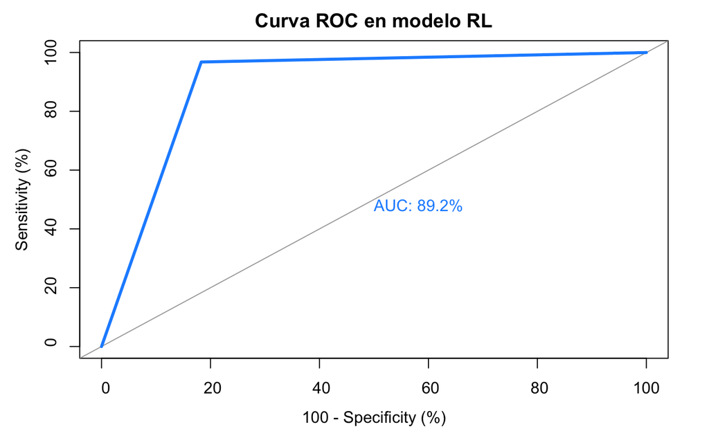

```r
title('Curva ROC en modelo RL')
```

La curva roc y el valor AUC de este modelo de Regresión Logística tienen mejores resultados con el modelo RF. Este modelo se acerca al modelo RF pero es más óptimo este último.

## Uso de Deep Learning con librería keras

#### Preprocesamiento de datos

Data Augmentation para el conjunto de datos de entrenamiento y reescalado para todos los conjuntos.

```r
#Create Keras Generators

set.seed(123)

# Uso de data augmentation en el conjunto de datos de entrenamiento
# Uso de la función image_data_generator de keras para hacer data augmentation
dataaugmentation = image_data_generator(
  # Sólo utilizo el reescalado de píxeles en el rango de 0 a 255.
  rescale = 1/255,
  rotation_range = 5,
  width_shift_range = 0.1,
  height_shift_range = 0.05,
  shear_range = 0.1,
  zoom_range = 0.15,
  horizontal_flip = TRUE,
  vertical_flip = FALSE,
  fill_mode = "reflect"
)

batchsize = 32

# Función para generar datos a partir de imágenes en un directorio.
dataaugmentation_ <- function(dataset_choosen, datagen_choosen) {
  flow_images_from_directory(
    dataset_choosen,                            # Target directory
    datagen_choosen,                        # Data generator
    classes = c('NORMAL', 'PNEUMONIA'), # NORMAL=1, PNEUMONIA=2
    target_size = c(224, 224),            # Resizes all images
    batch_size = batchsize,
    class_mode = "categorical",
    shuffle = T,
    seed = 123
  )
}

train_aug <- dataaugmentation_(train_data, dataaugmentation)
```

```
Found 4478 images belonging to 2 classes.
```

```r
val_aug <- dataaugmentation_(val_data, image_data_generator(rescale = 1/255))
```

```
Found 344 images belonging to 2 classes.
```

```r
#test_aug <- dataaugmentation_(test_data, image_data_generator(rescale = 1/255))
```

#### Generación del modelo

Uso de Transfer learning

```r
# Uso de Transfer learning con los pesos de inception resnet V2.
cnn <- application_inception_resnet_v2(
  weights = "/Users/saranavarromedina/Desktop/inception_resnet_v2_weights_tf_dim_ordering_tf_kernels_notop.h5",
  include_top = FALSE,
  input_shape = c(224, 224, 3)
)
```

```
2022-08-23 18:51:44.074560: I tensorflow/core/platform/cpu_feature_guard.cc:193] This TensorFlow binary is optimized with oneAPI Deep Neural Network Library (oneDNN) to use the following CPU instructions in performance-critical operations:  AVX2 FMA
To enable them in other operations, rebuild TensorFlow with the appropriate compiler flags.
```

```r
# Creación del modelo con diferentes capas
keras_model <- keras_model_sequential() %>%
  cnn %>%
  layer_global_average_pooling_2d(trainable = T) %>%
  layer_dropout(rate = 0.2, trainable = T) %>%
  layer_dense(units = 224, activation = "relu", trainable = T) %>%
  layer_dense(units = 2, activation = "softmax", trainable = T)

# Congelación de los pesos, no entrenamiento
freeze_weights(cnn)

set.seed(123)

# Compilación del modelo con función de pérdida y métrica
keras_model %>% compile(
  loss = "categorical_crossentropy",
  optimizer = optimizer_rmsprop(learning_rate = 1e-6),
  metrics = c("accuracy")
)

training_step_size = ceiling(length(list.files(train_data, recursive = T)) / batchsize)
validation_step_size = ceiling(length(list.files(val_data, recursive = T)) / batchsize)

# Proporción de imágenes con diagnóstico normal VS neumonía:
class_imbalance_prop <- length(list.files(paste(train_data, '/NORMAL/', sep = ""), recursive = T)) / length(list.files(paste(train_data, '/PNEUMONIA/', sep = ""), recursive = T))
```

```r
# Entrenamiento del modelo
set.seed(123)

keras_model %>% fit(
  train_aug,
  steps_per_epoch = 20,#100,
  class_weight = list("0"=1,"1"=class_imbalance_prop),#ajuste para desequilibrio de clases
  epochs = 20,#30,
  validation_data = val_aug,
  validation_steps = validation_step_size
)
```

#### Predicción

```r
# Predicciones sobre el conjunto de datos de testeo.
#test_aug <- dataaugmentation_(test_data, image_data_generator(rescale = 1/255))
keras_pred = predict(keras_model,test_aug, steps = length(list.files(test_data, recursive = T)))
```

```
WARNING:tensorflow:Your input ran out of data; interrupting training. Make sure that your dataset or generator can generate at least `steps_per_epoch * epochs` batches (in this case, 1034 batches). You may need to use the repeat() function when building your dataset.
```

```r
# Limpieza para evaluar el modelo
keras_pred_prob <- as.data.frame(keras_pred)
colnames(keras_pred_prob) <- c('NORMAL','PNEUMONIA')
keras_pred_prob$prob_chosen <- ifelse(keras_pred_prob$NORMAL>0.5,keras_pred_prob$NORMAL, keras_pred_prob$PNEUMONIA)
keras_pred_prob$prediction <- ifelse(keras_pred_prob$NORMAL>0.5,'NORMAL', 'PNEUMONIA')
keras_pred_prob$actual <- ifelse(test_aug$classes==0,'NORMAL','PNEUMONIA')
```

#### Evaluación del modelo

```r
keras_stats <- statistics(as.factor(keras_pred_prob$prediction), as.factor(keras_pred_prob$actual))
```

```
[1] "El estadístico kappa es de 0.007."
[1] "El estadístico recall, la proporción de predicciones de neumonías correctamente clasificadas entre todas las neumonías, es de 0.511."
[1] "El positive predictive value, la proporción de las predicciones de neumonías que son realmente neumonías, es de 0.747."
[1] "El estadístico specifity, la proporción de predicciones de condición normal correctamente clasificadas entre todas las condiciones normales, es de 0.511."
```

```r
library(pROC)
roc(ifelse(keras_pred_prob$prediction=='NORMAL',0,1),ifelse(keras_pred_prob$actual=='NORMAL',0,1), plot = TRUE,
    asp=NA,
    legacy.axes = TRUE,
    percent = TRUE,
    col = "#1E90FF",
    lwd = 3,
    print.auc = TRUE)
```

```
Call:
roc.default(response = ifelse(keras_pred_prob$prediction == "NORMAL",     0, 1), predictor = ifelse(keras_pred_prob$actual == "NORMAL",     0, 1), percent = TRUE, plot = TRUE, asp = NA, legacy.axes = TRUE,     col = "#1E90FF", lwd = 3, print.auc = TRUE)

Data: ifelse(keras_pred_prob$actual == "NORMAL", 0, 1) in 508 controls (ifelse(keras_pred_prob$prediction == "NORMAL", 0, 1) 0) < 526 cases (ifelse(keras_pred_prob$prediction == "NORMAL", 0, 1) 1).
Area under the curve: 50.35%
```

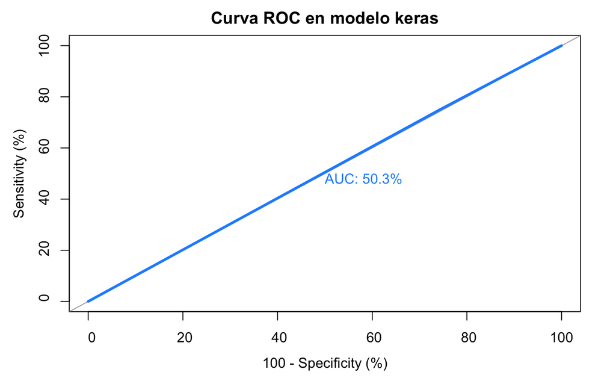

```r
title('Curva ROC en modelo keras')
```

La curva ROC es mala puesto que la sensibilidad (verdaderos positivos) es igual a la proporción de falsos positivos, la curva es la diagonal de (0,0) a (1,1).

```r
keras_model %>% evaluate(test_aug)
```

```
     loss  accuracy
0.5950548 0.6798840
```

Esperaba que el uso de librerías de Deep Learning mejoraran los valores de los estadísticos, sin embargo, no se consiguen buenos resultados, en términos generales.

# Conclusión

Ningún modelo es lo suficientemente fiable como para llevarlo a producción. Dado que son predicciones diagnósticas considero que todos los estadísticos evaluados deberían sobrepasar el 0.95. Sin embargo, **el modelo más aceptable sería el de Random Forest** por su valor de Kappa (0.855), por sus pocos errores tipo I (0.03%) y por tener unos estadísticos muy aceptables (>0.9 excepto Kappa).